# Project 2: Data Mining, Classification, Prediction

### Regression/Numeric Prediction

```r
# Linear Regression Model Code
library("rpart.plot")

fit <- train(murder ~ ., data = Guns, method = "rpart")
fit
```

```
## CART
##
## 1173 samples
##   13 predictor
##
## No pre-processing
## Resampling: Bootstrapped (25 reps)
## Summary of sample sizes: 1173, 1173, 1173, 1173, 1173, 1173, ...
## Resampling results across tuning parameters:
##
##   cp         RMSE      Rsquared   MAE
##   0.0690070  3.572909  0.7606842  2.330954
##   0.1407004  4.455798  0.6183110  3.086796
##   0.6446476  6.265608  0.5135136  3.776913
##
## RMSE was used to select the optimal model using the smallest value.
## The final value used for the model was cp = 0.069007.
```

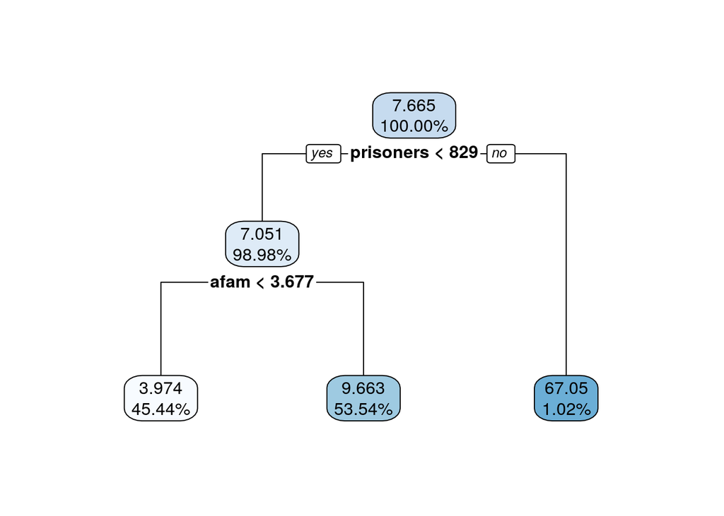

```r
rpart.plot(fit$finalModel, digits = 4)
```

```r
# MSE for the overall dataset
fit1 <- lm(murder ~ ., data = Guns)
msehat <- predict(fit1)
mean((Guns$murder - msehat)^2)  #MSE
```

```
## [1] 4.413099
```

```r
# Cross-Validation of Regression Model
set.seed(1234)
k = 10  #choose number of folds

data <- Guns[sample(nrow(Guns)), ]  #randomly order rows
folds <- cut(seq(1:nrow(Guns)), breaks = k, labels = F)  #create folds

diags <- NULL
for (i in 1:k) {
    train <- data[folds != i, ]
    test <- data[folds == i, ]

    ## Fit linear regression model to training set
    fit <- lm(murder ~ ., data = Guns)

    ## Get predictions/y-hats on test set (fold i)
    yhat <- predict(fit, newdata = test)

    ## Compute prediction error (MSE) for fold i
    diags <- mean((test$murder - yhat)^2)
}

## Average MSE across all folds (much higher error)!
mean(diags)
```

```
## [1] 4.070139
```

### Python

```r
library(reticulate)
use_python("/usr/bin/python3", required = F)
hi <- "Hello"
sent_1 <- " Merry Christmas"
```

```python
# python code
hi="world"
print(r.hi,hi)
```

```
## Hello world
```

```python
sent_2 = "and a Happy New Year"
print(r.sent_1,sent_2)
```

```
##  Merry Christmas and a Happy New Year
```

```r
# r code
cat(c(hi, py$hi))
```

```
## Hello world
```

```r
cat(c(sent_1, py$sent_2))
```

```
##  Merry Christmas and a Happy New Year
```

*Under the {R} section, by using py$, I was able to access Python-defined objects. Similarly, under the {python} section, by using r., I was able to access the R-defined objects. In doing so, I was able to share objects between R and python.*

### Concluding Remarks

Conclusively, upon doing data mining, data classification, and data prediction, I was able to further explore the informative natural grouping in the dataset and further analyze them to interpret their relationships. All in all, the Area Under the ROC Curve (AUC) results from the different classifier models were shown to be good and great. Therefore, we can interpret the AUC as the probability that a randomly selected person from a state allowing guns has a higher rate of crimes than a randomly selected person from a state not allowing guns.